# Can Sentiment Analysis Predict Stock Performance?

## Introduction

Stock - Type of financial security that represents a fraction of the ownership of the company

Stock Market (in my opinion) - A holistic representation of what every investor believes about every company (Fears, Doubts, Expectations, Greed, etc.)

Beliefs about specific companies are verbalized in online forums everyday (Reddit, Twitter, Discord, etc.)

How can we quanitfy these beliefs? Are they indicative of anything? Are such beliefs reflected in the stock performance?

## Research Question

**Does online sentiment of a specific company’s stock accurately reflect how that stock performs on a given day?**

## Methods + Data

**PushPull API**: Data Collection of Reddit Comments (More Accessible Version of Pushshift)

**Stock Data**: 1/1/2023 - 1/1/2024 Stock Data from AAPL, TSLA, and JPM (Investing.com)

**NRC Emotion Lexicon**: From the tidytext package

**Bing Liu Lexicon**: From the tidytext package

**AFINN Sentiment Lexicon**: From the tidytext package

**Chat GPT 4o**: For coding help and data wrangling

## Process

1. Write a function to extract reddit data

## Process

1. Write a function to extract reddit data
2. Use Tokenization on the Reddit data by word and bind sentiments to them

## Process

1. Write a function to extract reddit data
2. Use Tokenization on the Reddit data by word and bind sentiments to them
3. Create a sentiment score per day based on the positive and negative words in the reddit posts

## Process

1. Write a function to extract reddit data
2. Use Tokenization on the Reddit data by word and bind sentiments to them
3. Create a sentiment score per day based on the positive and negative words in the reddit posts
4. Attach stock data of the three companies through utilizing left_join

## Process

1. Write a function to extract reddit data
2. Use Tokenization on the Reddit data by word and bind sentiments to them
3. Create a sentiment score per day based on the positive and negative words in the reddit posts
4. Attach stock data of the three companies through utilizing left_join
5. Determine the percentage of the days where the pos/neg sentiments correlated w/ positive or negative return

# Step 1

## Pushpull API

- Relatively easy to use
- Free, there is no price per API request
- Extracts a random 100 comments off of reddit based on certain parameters
  - I used…
    - Time for before and after in Epoch (1672549200) (86400)
    - Q: Search Term ($[Stock Ticker])

## Code for Web Scraping Reddit

```r
library(httr)
library(jsonlite)

start_time <- 1672549200
end_time <- start_time + 86400

#Getting the tibble for a random assortment 100 reddit comments mentioning $AAPL
#over the course of a year per each day
tibble_list_aapl <- list()
for (i in 1:365) {
  response <- GET("https://api.pullpush.io/reddit/search/comment/",
                  query = list(q = "$AAPL",
                               after = start_time + ((i-1) * 86400),
                               before = (start_time + (i * 86400))))
  response_content <- content(response, "text")
  parsed <- parse_json(response_content)
  tibble_list_aapl[[i]] <- tibble(col1 = parsed$data) |>
    unnest_wider(col1) |>
    select(body, created_utc)
}
#Create a tibble with the text and the time the comment was created
final_df_aapl = bind_rows(tibble_list_aapl)
```

# Step 2-3

## Tokenization + Sentiment Attachment

- I utilized tidytext to import three different sentiment packages
  - nrc - pos/neg + emotional data
  - bing - pos/neg/neutral
  - AFINN - score running from -5 to 5, with -5 being the most negative and 5 being the most positive
- I tokenized by word, indicated with +1 or -1 whether positive or negative, then got the sentiment differential by taking the sum over each day

## Code for Binding Sentiments

```r
library(tidytext)

#Function for Extracting Sentiment Data and Creating a Sentiment Differential
sentiment <- function(tibble) {
  sentiment_analysis <- tibble |>
    unnest_tokens(input = "body", output = "word", token = "words") |>
    inner_join(nrc, by = "word", relationship = "many-to-many") |>
    filter(sentiment %in% c("positive", "negative")) |>
    mutate(sentiment_score = ifelse(sentiment == "positive", 1, -1)) |>
    group_by(day) |>
    summarize(sentiment_differential = sum(sentiment_score))
  return(sentiment_analysis)
}
```

## Code for Binding Sentiments

Sample Sentiment Score Table NRC - AAPL

| X | day | sentiment_differential |
| --- | --- | --- |
| 1 | 01/01/2023 | 32 |
| 2 | 01/02/2023 | 86 |
| 3 | 01/03/2023 | 48 |
| 4 | 01/04/2023 | 46 |
| 5 | 01/05/2023 | 44 |
| 6 | 01/06/2023 | 17 |

# Step 4-5

## Code for Determining Matched %

```r
#Importing stock data
AAPL_stock_data <- read.csv(here("Apple Stock Price History.csv"))

#Fixing the dates on the sentiment tibble
AAPL_sentiment <- AAPL_sentiment |>
  mutate(day = format(as.Date(day - 1, origin = "2023-1-1"), "%m/%d/%Y")) |>
  mutate(day = as.character(day))

#Creating the tibble with matched column
final_AAPL_df <- AAPL_stock_data |>
  left_join(AAPL_sentiment, by = "day") |>
  mutate(inc_dec = ifelse(Change.. > 0, 1, 0)) |>
  mutate(pos_neg_sentiment = ifelse(sentiment_differential > 0, 1, 0)) |>
  mutate(matched = ifelse(inc_dec == pos_neg_sentiment, 1, 0))

#Proportion of matched days over the year
sum(final_AAPL_df$matched)/250
```

## Matched Tibble of the 3 Stocks with the 3 Different Sentiment Packages

Matched Tibble

| …1 | sentiment | AAPL | TSLA | JPM |
| --- | --- | --- | --- | --- |
| 1 | nrc | 0.556 | 0.516 | 0.560 |
| 2 | bing | 0.520 | 0.564 | 0.540 |
| 3 | AFINN | 0.552 | 0.556 | 0.548 |

# Results

## Did sentiments accurately predict stock performance?

- In short, not really.
- The sentiments failed to capture most of the negative trading days.

```
  pos_neg_sentiment   n
1                -1  13
2                 1 237
```

```
  inc_dec   n
1      -1 110
2       1 140
```

## Graphical Representation of this Issue

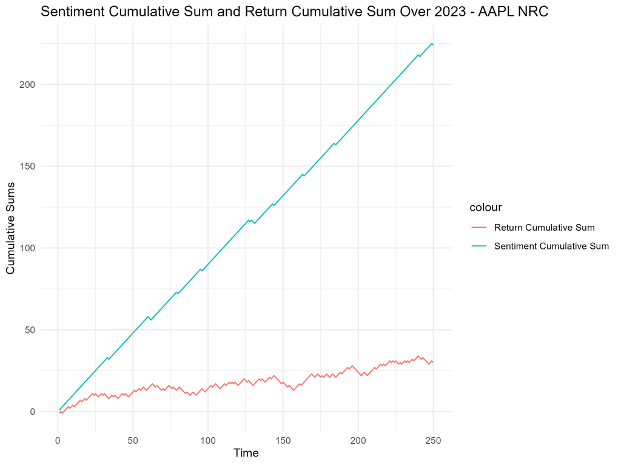

# Challenges

## Data Issues

- Reddit is primarily made up of retail investors, not huge hedge funds reporting on the company
  - Equity reports would provide a better data set to run sentiment analysis through
  - Access issues
- The sentiment packages are good, but they are not specialized for financial jargon
  - Ex. bullish and bearish would not be represented as positive or negative in any of the sentiment packages

## Interpretation Issues

- The matched variable is based off of the dummy variables of pos_neg_sentiment and inc_dec
  - If you were to randomly pick 1s and 0s, you might get a higher match % than I did
- Coincidence or Causality?